# Tree-Based Models (Bagging, Boosting and Random Forest)

### Data Pre-processing

```python
#Converting all variables into numeric.
from sklearn import model_selection, preprocessing
for c in vgsales_data.columns:
    if vgsales_data[c].dtype == 'object':
        lbl = preprocessing.LabelEncoder()
        lbl.fit(list(vgsales_data[c].values))
        vgsales_data[c] = lbl.transform(list(vgsales_data[c].values))
vgsales_data.head(3)
```

| Year | Rank | Name | Platform | Genre | Publisher | NA_Sales | EU_Sales | JP_Sales | Other_Sales | Global_Sales |
| --- | --- | --- | --- | --- | --- | --- | --- | --- | --- | --- |
| 1980.0 | 259 | 500 | 0 | 8 | 53 | 4.00 | 0.26 | 0.0 | 0.05 | 4.31 |
| 1980.0 | 6319 | 1030 | 0 | 3 | 21 | 0.25 | 0.02 | 0.0 | 0.00 | 0.27 |
| 1980.0 | 1971 | 1979 | 0 | 3 | 53 | 0.99 | 0.05 | 0.0 | 0.01 | 1.05 |

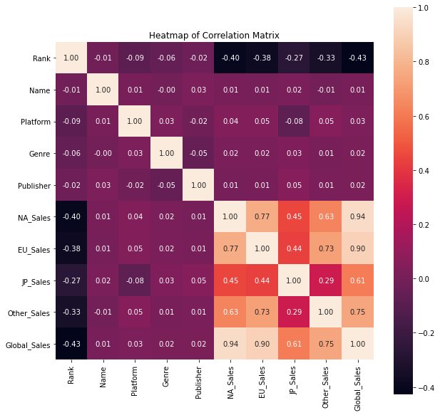

```python
corr=vgsales_data.corr()
corr = (corr)
plt.figure(figsize=(10,10))
ax = sns.heatmap(corr, cbar = True,  square = True, annot=True, fmt= '.2f',annot_kws=

{'size': 10},
            xticklabels=corr.columns.values,
            yticklabels=corr.columns.values)
ax.set_title('Heatmap of Correlation Matrix')
```

We converted all the categorical variables into numeric, from the statistical point of view we cannot calculate anything with qualitative data, we need to recode them numerically. The heatmap above is showing collineary between regional sales and global sales, which is pretty obvious. Luckily, tree-model algorithms are immune to multicollinearity by nature. There is no assumptions on relationship between features. In this exercise, we predict global sales given all other features namely the 'Rank', 'Name' of the videogame, 'Platform' the games is played, Genre, Publisher, NA_Sales, EU_Sales, JP_Sales, and Other_Sales. We wanted to include all variables to see how tree models identify feature importance. Before doing any analysis we need to prepare the dataset like treating missing values by imputing median or mean, and normalizing the data in order to achieve a much more reliable results. We split the dataset into train and test set. The training set contains a known output and the model learns on this data in order to be generalized to other data later on. We have the test dataset in order to test our model's prediction. We need a model that performs well on dataset that it has never seen before.

```python
#Train test split
X = vgsales_data.drop(["Global_Sales"], axis = 1)
y = vgsales_data[["Global_Sales"]]
X_train, X_test, y_train, y_test = train_test_split(X, y, test_size=0.2, random_state=42)
```

```python
# Normalize output variable 'Global_Sales' using MinMaxScaler
from sklearn.preprocessing import RobustScaler, MinMaxScaler
from sklearn.pipeline import Pipeline
from sklearn.impute import SimpleImputer

#Normalize Global sales
y_pipeline = Pipeline(steps=[('imputation', SimpleImputer(strategy='median')),
                               ('scaling', RobustScaler())])

y_train_p = y_pipeline.fit_transform(y_train[['Global_Sales']])
y_test_p =  y_pipeline.fit_transform(y_test[['Global_Sales']])

#Normalize all feature variables
X_cat_pipeline = Pipeline(steps=[('imputation', SimpleImputer(strategy='constant', )),
                               ('scaling', RobustScaler())])

X_train_p = X_cat_pipeline.fit_transform(X_train)
X_test_p = X_cat_pipeline.fit_transform(X_test)
```

### Modelling

```python
# Import ML algorithms for model comparison of Random Forest Regressor and other models
from sklearn.linear_model import LinearRegression, Lasso, Ridge,  ElasticNet
from sklearn.ensemble import RandomForestRegressor, GradientBoostingRegressor, BaggingRegressor
from sklearn.tree import DecisionTreeRegressor
from sklearn.metrics import r2_score, mean_squared_error
import sklearn.metrics as metrics
```

#### Decision Tree

```python
#Decision Tree Regression
dec_tree = DecisionTreeRegressor(criterion='mse', max_depth=3)
dec_tree.fit(X_train_p, y_train_p)
dec_tree_predict = dec_tree.predict(X_test_p)

#Model evaluation
tree_r2 = r2_score( y_test_p, dec_tree_predict)
tree_mse = mean_squared_error(y_test_p, dec_tree_predict)
accuracy = round (100 - np.mean(tree_mse),2)

print("accuracy: ", accuracy)
print("tree_r2: ", tree_r2)
print("tree_mse: ", tree_mse)
```

```
accuracy:  96.87
tree_r2:  0.7575613535451354
tree_mse:  3.1346778450942776
```

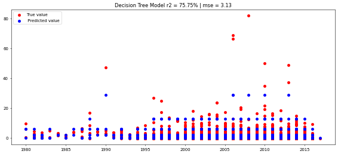

```python
fig, ax = plt.subplots(figsize=(14,6), dpi=50)
ax.scatter(y_test.index, y_test_p, label="True value", color="red")
ax.scatter(y_test.index, dec_tree_predict , label=" Predicted value" , color="blue")
plt.legend(loc='upper left')
ax.set_title('Decision Tree Model r2 = 75.75% | mse = 3.13')
plt.show()
```

```
Rank_ 0:	  0.85132
Name_ 1:	  0.00000
Platform_ 2:	  0.00000
Genre_ 3:	  0.00000
Publisher_ 4:	  0.00000
NA_Sales_ 5:	  0.00000
EU_Sales_ 6:	  0.14868
JP_Sales_ 7:	  0.00000
Other_Sales_ 8:	  0.00000
```

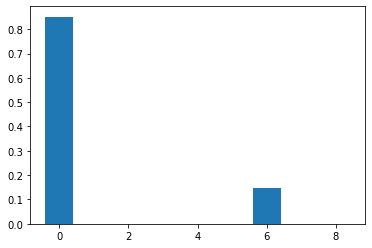

```python
#Feature of Importance Decision tree
importance = dec_tree.feature_importances_

featureList = []

for feature in X_train:
    featureList.append(feature)

# summarize feature importance
for i,v in enumerate(importance):
    print(featureList[i] + "_" , "%0d:\t  %.5f" % (i,v))

# plot feature importance
plt.bar([x for x in range(len(importance))], importance)
plt.show()
```

#### Boosting

```python
#BoostingRegressor
#y_train = y_train.values.ravel()
boosting_model = GradientBoostingRegressor()
boosting_model.fit(X_train_p, y_train_p)
boosting_predict = boosting_model.predict(X_test_p)


#Model Evaluation
boosting_r2 = r2_score( y_test_p, boosting_predict)
boosting_mse = mean_squared_error(y_test_p, boosting_predict)
accuracy = round (100 - np.mean(boosting_mse),2)

print("accuracy: ", accuracy)
print("boosting_r2: ", boosting_r2)
print("boosting_mse: ", boosting_mse)
```

```
accuracy:  97.04
boosting_r2:  0.7708178191628691
boosting_mse:  2.9632746893523567
```

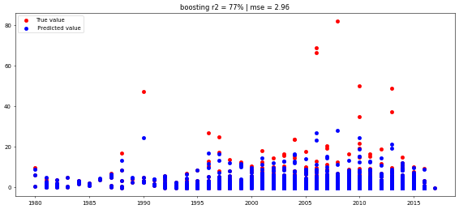

```python
fig, ax = plt.subplots(figsize=(14,6), dpi=50)
ax.scatter(y_test.index, y_test_p, label="True value", color="red")
ax.scatter(y_test.index, boosting_predict , label=" Predicted value" , color="blue")
plt.legend(loc='upper left')
ax.set_title('boosting r2 = 77% | mse = 2.96')
plt.show()
```

```
Rank_ 0:	  0.90061
Name_ 1:	  0.00000
Platform_ 2:	  0.00000
Genre_ 3:	  0.00280
Publisher_ 4:	  0.00000
NA_Sales_ 5:	  0.04006
EU_Sales_ 6:	  0.04563
JP_Sales_ 7:	  0.00022
Other_Sales_ 8:	  0.01069
```

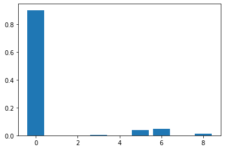

```python
#Feature of Importance Decision tree
importance = boosting_model.feature_importances_

featureList = []

for feature in X_train:
    featureList.append(feature)

# summarize feature importance
for i,v in enumerate(importance):
    print(featureList[i] + "_" , "%0d:\t  %.5f" % (i,v))

# plot feature importance
plt.bar([x for x in range(len(importance))], importance)
plt.show()
```

Boosting gave is r2 = 77%, MSE 2.96 and accuracy 97%. The company overall rank is also the most important feature variable, with 90% contribution to the model performance europe and north america sales also contributed 5% and 4% respectively. 77% of the variance can be explained by the boosting model which is just 2% more than the decision tree performance in the dataset. If we look at the graph, we almost predicted the true value with 97% accuracy.